# 3장 데이터 변형

43

2020 9 30

### 3.1 들어가기

(43p) 데이터를 좀 더 쉽게 사용할 수 있도록 새로운 변수나 요약값을 만들어야 할 수도 있고, 아니면 변수 이름을 변경하거나 관측값들을 재정렬해야 되는 경우가 종종 있습니다. 이 장에서는 dplyr 패키지와 2013년 뉴욕시 출발 항공편에 대한 새로운 데이터셋을 이용하여 데이터 변형 방법을 배울 것입니다.

#### 3.1.1 준비하기

3장에서는 아래와 같은 패키지를 사용하기 때문에 사전 준비가 필요합니다. 앞서 1장에서 배웠듯이 패키지는 한 번만 설치하면 되지만, 새로운 세션을 시작할 때마다 다시 로드해야 합니다.

```r
install.packages("nycflights13")
install.packages("tidyverse")
library(nycflights13)
library(tidyverse)
```

#### 3.1.2 nycflights13

dplyr의 기본 데이터 작업(manipulation-머니펼레이션) 동사를 탐색하기 위해서 `nycflights13::flights`를 사용할 것입니다. 이 데이터프레임에는 뉴욕시에서 2013년에 출발한 모든 항공편이 포함되어 있습니다.

```r
flights
```

```
## # A tibble: 336,776 x 19
##     year month   day dep_time sched_dep_time dep_delay arr_time sched_arr_time
##    <int> <int> <int>    <int>          <int>     <dbl>    <int>          <int>
##  1  2013     1     1      517            515         2      830            819
##  2  2013     1     1      533            529         4      850            830
##  3  2013     1     1      542            540         2      923            850
##  4  2013     1     1      544            545        -1     1004           1022
##  5  2013     1     1      554            600        -6      812            837
##  6  2013     1     1      554            558        -4      740            728
##  7  2013     1     1      555            600        -5      913            854
##  8  2013     1     1      557            600        -3      709            723
##  9  2013     1     1      557            600        -3      838            846
## 10  2013     1     1      558            600        -2      753            745
## # ... with 336,766 more rows, and 11 more variables: arr_delay <dbl>,
## #   carrier <chr>, flight <int>, tailnum <chr>, origin <chr>, dest <chr>,
## #   air_time <dbl>, distance <dbl>, hour <dbl>, minute <dbl>, time_hour <dttm>
```

열 이름(year, month 등) 아래의 줄임말 행은 각 변수의 유형을 설명합니다.

- `int` 정수
- `dbl` 더블형, 또는 실수
- `chr` 문자형 벡터, 혹은 문자열
- `dttm` 데이트-타임형(날짜 + 시간)

#### 3.1.3 dplyr 기초

이 장에서 대부분의 데이터 작업 문제를 풀 수 있는 다섯 개의 핵심 dplyr 함수들을 배울 것입니다.

- `fliter()` 값을 기준으로 선택하라
- `arrange()` 행을 재정렬하라
- `select()` 이름으로 변수를 선택하라
- `mutate()` 기존 변수들의 함수로 새로운 변수를 생성하라
- `summarize()` 많은 값을 하나의 요약값으로 합쳐라

이것들은 모두 `group_by()`와 함께 사용할 수 있는데, 이는 전체 데이터셋에 동작하지 않고 그룹마다 동작하도록 각 함수의 범위를 변경합니다. 이 여섯 함수가 데이터 작업 언어에서 **동사**가 됩니다. 이 속성들을 함께 이용하면 여러 단순한 단계를 쉽게 연결하여 복잡한 결과를 얻을 수 있습니다.

1. 첫 인수는 데이터프레임입니다.
2. 그 이후의 인수들은 (따옴표가 없는) 변수 이름을 사용하여 데이터프레임에 무엇을 할지를 설명합니다.
3. 결과는 새로운 데이터프레임입니다.

### 3.2 filter()로 행 필터링하기

(45p)

`filter()`를 이용하면 값을 기준으로 데이터를 서브셋 할 수 있습니다. 첫 번째 인수는 데이터프레임 이름이고, 두 번째 이후의 인수들은 데이터프레임을 필터링하는 표현식들입니다. 예를 들어 1월 1일 항공편 모두를 다음과 같이 선택할 수 있습니다.

```r
filter(flights, month == 1, day == 1)
```

```
## # A tibble: 842 x 19
##     year month   day dep_time sched_dep_time dep_delay arr_time sched_arr_time
##    <int> <int> <int>    <int>          <int>     <dbl>    <int>          <int>
##  1  2013     1     1      517            515         2      830            819
##  2  2013     1     1      533            529         4      850            830
##  3  2013     1     1      542            540         2      923            850
##  4  2013     1     1      544            545        -1     1004           1022
##  5  2013     1     1      554            600        -6      812            837
##  6  2013     1     1      554            558        -4      740            728
##  7  2013     1     1      555            600        -5      913            854
##  8  2013     1     1      557            600        -3      709            723
##  9  2013     1     1      557            600        -3      838            846
## 10  2013     1     1      558            600        -2      753            745
## # ... with 832 more rows, and 11 more variables: arr_delay <dbl>,
## #   carrier <chr>, flight <int>, tailnum <chr>, origin <chr>, dest <chr>,
## #   air_time <dbl>, distance <dbl>, hour <dbl>, minute <dbl>, time_hour <dttm>
```

dplyr 함수들은 입력을 절대 수정하지 않기 때문에, 결과를 저장하려면 할당 연산자 `<-`를 사용해야 합니다.

```r
jan1 <- filter(flights, month == 1, day == 1)
```

R은 결과를 출력하거나 변수에 저장합니다. 둘 다 수행되게 하려면 할당문을 괄호로 묶으면 됩니다.

```r
(dec25 <- filter(flights, month == 12, day == 25))
```

```
## # A tibble: 719 x 19
##     year month   day dep_time sched_dep_time dep_delay arr_time sched_arr_time
##    <int> <int> <int>    <int>          <int>     <dbl>    <int>          <int>
##  1  2013    12    25      456            500        -4      649            651
##  2  2013    12    25      524            515         9      805            814
##  3  2013    12    25      542            540         2      832            850
##  4  2013    12    25      546            550        -4     1022           1027
##  5  2013    12    25      556            600        -4      730            745
##  6  2013    12    25      557            600        -3      743            752
##  7  2013    12    25      557            600        -3      818            831
##  8  2013    12    25      559            600        -1      855            856
##  9  2013    12    25      559            600        -1      849            855
## 10  2013    12    25      600            600         0      850            846
## # ... with 709 more rows, and 11 more variables: arr_delay <dbl>,
## #   carrier <chr>, flight <int>, tailnum <chr>, origin <chr>, dest <chr>,
## #   air_time <dbl>, distance <dbl>, hour <dbl>, minute <dbl>, time_hour <dttm>
```

#### 3.2.1 비교 연산

필터링을 효과적으로 사용하려면 비교 연산자를 사용하여 원하는 관측값을 선택하는 방법을 알아야 합니다. R에는 다음과 같은 표준연산자군이 있습니다.

- `>` 크다
- `>=` 크거나 같다
- `<` 작다
- `<=` 작거나 같다
- `!=` 같지 않다
- `==` 같다

R을 배우기 시작할 때 가장 범하기 쉬운 실수는, 같음을 테스트할 때 `==` 대신 `=`를 사용하는 것입니다. 이런 실수를 하면 오류가 발생하면서 해당 내용을 알려줍니다.

컴퓨터는 무한대 수를 저장할 수 없어서 눈앞에 보이는 숫자는 근사값이라는 것을 기억해야 합니다. 따라서 숫자를 비교할 때 `==` 대신, `near()`를 사용해야 합니다.

```r
near(sqrt(2) ^ 2, 2)
```

```
## [1] TRUE
```

```r
near(1 / 49 * 49, 1)
```

```
## [1] TRUE
```

다음 코드는 11월이나 12월에 출발한 항공편 모두를 찾습니다.

```r
filter(flights, month == 11 | month == 12)
```

```r
nov_dec <- filter(flights, month %in% c(11, 12))
```

드 모르간 법칙을 이용하여 복잡한 서브셋 동작을 단순화할 수도 있습니다. 앞서 설명했듯이 둘 다 수행되게 하려면 할당문을 괄호로 묶으면 됩니다. 예를 들어 (출발 혹은 도착에서) 두 시간 이상 지연되지 않은 항공편을 모두 찾고 싶다면 다음의 두 필터 중 하나를 사용해도 됩니다.

```r
filter(flights, !(arr_delay > 120 | dep_delay > 120))
filter(flights, arr_delay <= 120, dep_delay <= 120)
```

filter() 안의 표현식이 복잡하고 여러 개 나열되기 시작하면, 항상 이들을 명시적 변수들로 만드는 것을 고려해야 합니다. 이렇게 하면 작업을 확인하기 훨씬 쉬워집니다.

#### 3.2.3 결측값

R에서 비교를 까다롭게 만드는 중요한 특징은 결측값, 즉 NA(not availiable, 이용불가)입니다. NA는 모르는 값을 나타내므로, 모르는 값이 연관된 연산의 결과도 대부분 모르는 값이 됩니다.

```r
# x를 메리의 나이라고 하자, 우리는 그녀가 몇 살인지 모른다.
x <- NA
# y를 존의 나이라고 하자. 우리는 그가 몇 살인지 모른다.
y <- NA
# 존과 메리는 같은 나이인가?
x == y
[1] NA
# 우린 모른다!
```

값이 결측인지를 확인하고 싶으면 `is.na()`를 사용합니다.

```r
x <- NA
is.na(x)
```

```
## [1] TRUE
```

filter()는 조건이 TURE인 열만 포함됩니다. FALSE와 NA 값들은 제외합니다. 결측값들은 남기려면 명시적으로 요청해야 합니다.

```r
df <- tibble(x = c(1, NA, 3))
filter(df, x > 1)
```

```
## # A tibble: 1 x 1
##       x
##   <dbl>
## 1     3
```

```r
filter(df, is.na(x) | x > 1)
```

```
## # A tibble: 2 x 1
##       x
##   <dbl>
## 1    NA
## 2     3
```

### 3.3 arrange()로 행 정렬하기

`arrange()`는 행을 선택하는 대신, 순서를 바꾼다는 것만 제외하고는 filter()와 유사하게 작동합니다. 데이터프레임과 정렬기준으로 지정할 열 이름 집합(혹은 복잡한 표현식)을 입력으로 합니다. 하나 이상의 열 이름을 제공하면 각 열은 이전 열의 동점값(tie) 상황을 해결하는 데 사용됩니다.

```r
arrange(flights, year, month, day)
```

```
## # A tibble: 336,776 x 19
##     year month   day dep_time sched_dep_time dep_delay arr_time sched_arr_time
##    <int> <int> <int>    <int>          <int>     <dbl>    <int>          <int>
##  1  2013     1     1      517            515         2      830            819
##  2  2013     1     1      533            529         4      850            830
##  3  2013     1     1      542            540         2      923            850
##  4  2013     1     1      544            545        -1     1004           1022
##  5  2013     1     1      554            600        -6      812            837
##  6  2013     1     1      554            558        -4      740            728
##  7  2013     1     1      555            600        -5      913            854
##  8  2013     1     1      557            600        -3      709            723
##  9  2013     1     1      557            600        -3      838            846
## 10  2013     1     1      558            600        -2      753            745
## # ... with 336,766 more rows, and 11 more variables: arr_delay <dbl>,
## #   carrier <chr>, flight <int>, tailnum <chr>, origin <chr>, dest <chr>,
## #   air_time <dbl>, distance <dbl>, hour <dbl>, minute <dbl>, time_hour <dttm>
```

내림차순으로 열을 재정렬하려면 `desc()`를 사용합니다.

```r
arrange(flights, desc(dep_delay))
```

```
## # A tibble: 336,776 x 19
##     year month   day dep_time sched_dep_time dep_delay arr_time sched_arr_time
##    <int> <int> <int>    <int>          <int>     <dbl>    <int>          <int>
##  1  2013     1     9      641            900      1301     1242           1530
##  2  2013     6    15     1432           1935      1137     1607           2120
##  3  2013     1    10     1121           1635      1126     1239           1810
##  4  2013     9    20     1139           1845      1014     1457           2210
##  5  2013     7    22      845           1600      1005     1044           1815
##  6  2013     4    10     1100           1900       960     1342           2211
##  7  2013     3    17     2321            810       911      135           1020
##  8  2013     6    27      959           1900       899     1236           2226
##  9  2013     7    22     2257            759       898      121           1026
## 10  2013    12     5      756           1700       896     1058           2020
## # ... with 336,766 more rows, and 11 more variables: arr_delay <dbl>,
## #   carrier <chr>, flight <int>, tailnum <chr>, origin <chr>, dest <chr>,
## #   air_time <dbl>, distance <dbl>, hour <dbl>, minute <dbl>, time_hour <dttm>
```

결측값은 항상 마지막에 정렬됩니다.

```r
df <- tibble(x = c(5, 2, NA))
arrange(df, x)
```

```
## # A tibble: 3 x 1
##       x
##   <dbl>
## 1     2
## 2     5
## 3    NA
```

```r
arrange(df, desc(x))
```

```
## # A tibble: 3 x 1
##       x
##   <dbl>
## 1     5
## 2     2
## 3    NA
```

### 3.4 select()로 열 선택하기

변수가 매우 많은 데이터셋을 만날 결우 첫 과제는 실제로 관심 있는 변수들로 좁히는 것입니다. `select()`와 변수 이름에 기반한 연산들을 이용하면 유용한 서브셋으로 신속하게 줌인(zoom in)해 볼 수 있습니다.

```r
# 이름으로 열 선택
select(flights, year, month, day)
```

```
## # A tibble: 336,776 x 3
##     year month   day
##    <int> <int> <int>
##  1  2013     1     1
##  2  2013     1     1
##  3  2013     1     1
##  4  2013     1     1
##  5  2013     1     1
##  6  2013     1     1
##  7  2013     1     1
##  8  2013     1     1
##  9  2013     1     1
## 10  2013     1     1
## # ... with 336,766 more rows
```

```r
# year과 day 사이의(경계 포함) 열 모두 선택
select(flights, year:day)
```

```
## # A tibble: 336,776 x 3
##     year month   day
##    <int> <int> <int>
##  1  2013     1     1
##  2  2013     1     1
##  3  2013     1     1
##  4  2013     1     1
##  5  2013     1     1
##  6  2013     1     1
##  7  2013     1     1
##  8  2013     1     1
##  9  2013     1     1
## 10  2013     1     1
## # ... with 336,766 more rows
```

```r
# year에서 day까지의(경계 포함) 열들을 제외한 열 모두 선택
select(flights, -(year:day))
```

```
## # A tibble: 336,776 x 16
##    dep_time sched_dep_time dep_delay arr_time sched_arr_time arr_delay carrier
##       <int>          <int>     <dbl>    <int>          <int>     <dbl> <chr>
##  1      517            515         2      830            819        11 UA
##  2      533            529         4      850            830        20 UA
##  3      542            540         2      923            850        33 AA
##  4      544            545        -1     1004           1022       -18 B6
##  5      554            600        -6      812            837       -25 DL
##  6      554            558        -4      740            728        12 UA
##  7      555            600        -5      913            854        19 B6
##  8      557            600        -3      709            723       -14 EV
##  9      557            600        -3      838            846        -8 B6
## 10      558            600        -2      753            745         8 AA
## # ... with 336,766 more rows, and 9 more variables: flight <int>,
## #   tailnum <chr>, origin <chr>, dest <chr>, air_time <dbl>, distance <dbl>,
## #   hour <dbl>, minute <dbl>, time_hour <dttm>
```

`select()` 안에서 사용할 수 있는 도우미 함수들

- `starts_with("abc")` ’abc로 시작하는 이름에 매칭
- `ends_with("xyz")` ’xyz’로 끝나는 이름에 매칭
- `contains("ijk")` ’ijk’를 포함하는 이름에 매칭
- `matches("(.)\\1")` 정규표현식에 매칭되는 변수들을 선택. 이 표현식은 반복되는 문자를 포함하는 변수에 매칭됩니다.
- `num_range("x", 1:3)` x1, x2, x3에 매칭

변수명 변경에 select()를 이용할 수 있지만, 명시적으로 언급하지 않은 모든 변수를 누락하기 때문에 유용하지 않습니다. 대신 select()의 변형인 `rename()`을 사용하면 명시적으로 언급하지 않은 모든 변수를 유지합니다.

```r
rename(flights, tail_num = tailnum)
```

```
## # A tibble: 336,776 x 19
##     year month   day dep_time sched_dep_time dep_delay arr_time sched_arr_time
##    <int> <int> <int>    <int>          <int>     <dbl>    <int>          <int>
##  1  2013     1     1      517            515         2      830            819
##  2  2013     1     1      533            529         4      850            830
##  3  2013     1     1      542            540         2      923            850
##  4  2013     1     1      544            545        -1     1004           1022
##  5  2013     1     1      554            600        -6      812            837
##  6  2013     1     1      554            558        -4      740            728
##  7  2013     1     1      555            600        -5      913            854
##  8  2013     1     1      557            600        -3      709            723
##  9  2013     1     1      557            600        -3      838            846
## 10  2013     1     1      558            600        -2      753            745
## # ... with 336,766 more rows, and 11 more variables: arr_delay <dbl>,
## #   carrier <chr>, flight <int>, tail_num <chr>, origin <chr>, dest <chr>,
## #   air_time <dbl>, distance <dbl>, hour <dbl>, minute <dbl>, time_hour <dttm>
```

다른 방법은 select()를 도우미 함수인 `everything()`과 함께 사용하는 것입니다. 몇 개의 변수를 데이터프레임의 시작 부분으로 옮기고 싶을 때 유용합니다.

```r
select(flights, time_hour, air_time, everything())
```

```
## # A tibble: 336,776 x 19
##    time_hour           air_time  year month   day dep_time sched_dep_time
##    <dttm>                 <dbl> <int> <int> <int>    <int>          <int>
##  1 2013-01-01 05:00:00      227  2013     1     1      517            515
##  2 2013-01-01 05:00:00      227  2013     1     1      533            529
##  3 2013-01-01 05:00:00      160  2013     1     1      542            540
##  4 2013-01-01 05:00:00      183  2013     1     1      544            545
##  5 2013-01-01 06:00:00      116  2013     1     1      554            600
##  6 2013-01-01 05:00:00      150  2013     1     1      554            558
##  7 2013-01-01 06:00:00      158  2013     1     1      555            600
##  8 2013-01-01 06:00:00       53  2013     1     1      557            600
##  9 2013-01-01 06:00:00      140  2013     1     1      557            600
## 10 2013-01-01 06:00:00      138  2013     1     1      558            600
## # ... with 336,766 more rows, and 12 more variables: dep_delay <dbl>,
## #   arr_time <int>, sched_arr_time <int>, arr_delay <dbl>, carrier <chr>,
## #   flight <int>, tailnum <chr>, origin <chr>, dest <chr>, distance <dbl>,
## #   hour <dbl>, minute <dbl>
```

### 3.5 mutate()로 새로운 변수 추가하기

`mutate()`는 기존 열들의 함수인 새로운 열을 추가하는 일을 합니다.

```r
# `mutate()`는 새로운 열을 항상 데이터셋 마지막에 추가하기 때문에, 새로운 변수를 보기 편하게 우선 더 좁은 데이터셋을 생성하겠습니다.
flights_sml <- select(flights,
  year:day,
  ends_with("delay"),
  distance,
  air_time
)
mutate(flights_sml,
  gain = dep_delay - arr_delay,
  speed = distance / air_time * 60
)
```

```
## # A tibble: 336,776 x 9
##     year month   day dep_delay arr_delay distance air_time  gain speed
##    <int> <int> <int>     <dbl>     <dbl>    <dbl>    <dbl> <dbl> <dbl>
##  1  2013     1     1         2        11     1400      227    -9  370.
##  2  2013     1     1         4        20     1416      227   -16  374.
##  3  2013     1     1         2        33     1089      160   -31  408.
##  4  2013     1     1        -1       -18     1576      183    17  517.
##  5  2013     1     1        -6       -25      762      116    19  394.
##  6  2013     1     1        -4        12      719      150   -16  288.
##  7  2013     1     1        -5        19     1065      158   -24  404.
##  8  2013     1     1        -3       -14      229       53    11  259.
##  9  2013     1     1        -3        -8      944      140     5  405.
## 10  2013     1     1        -2         8      733      138   -10  319.
## # ... with 336,766 more rows
```

```r
# 방금 생성한 열을 참조할 수 있습니다.
mutate(flights_sml,
  gain = dep_delay - arr_delay,
  hours = air_time / 60,
  gain_per_hour = gain / hours
)
```

```
## # A tibble: 336,776 x 10
##     year month   day dep_delay arr_delay distance air_time  gain hours
##    <int> <int> <int>     <dbl>     <dbl>    <dbl>    <dbl> <dbl> <dbl>
##  1  2013     1     1         2        11     1400      227    -9 3.78
##  2  2013     1     1         4        20     1416      227   -16 3.78
##  3  2013     1     1         2        33     1089      160   -31 2.67
##  4  2013     1     1        -1       -18     1576      183    17 3.05
##  5  2013     1     1        -6       -25      762      116    19 1.93
##  6  2013     1     1        -4        12      719      150   -16 2.5
##  7  2013     1     1        -5        19     1065      158   -24 2.63
##  8  2013     1     1        -3       -14      229       53    11 0.883
##  9  2013     1     1        -3        -8      944      140     5 2.33
## 10  2013     1     1        -2         8      733      138   -10 2.3
## # ... with 336,766 more rows, and 1 more variable: gain_per_hour <dbl>
```

```r
# 새 변수만을 남기고 싶다면 transmute()를 사용합니다.
transmute(flights,
  gain = dep_delay - arr_delay,
  hours = air_time / 60,
  gain_per_hour = gain / hours
)
```

```
## # A tibble: 336,776 x 3
##     gain hours gain_per_hour
##    <dbl> <dbl>         <dbl>
##  1    -9 3.78          -2.38
##  2   -16 3.78          -4.23
##  3   -31 2.67         -11.6
##  4    17 3.05           5.57
##  5    19 1.93           9.83
##  6   -16 2.5           -6.4
##  7   -24 2.63          -9.11
##  8    11 0.883         12.5
##  9     5 2.33           2.14
## 10   -10 2.3           -4.35
## # ... with 336,766 more rows
```

#### 3.5.1 유용한 생성 함수

`mutate()`와 사용할 수 잇는 변수 생성 함수가 많습니다. 이 함수들이 벡터화되어야 한다는 것이 핵심입니다. 즉, 벡터를 입력으로 하여 같은 개수의 값을 가진 벡터를 출력해야 합니다.

##### 산술 연산자 +, -, *, /, ^

’재활용 규칙’을 이용하여 이들은 모두 벡터화됩니다. 인수 하나가 단일 숫자인 경우에 가장 유용합니다. `air_time / 60`, `hours * 60 + minute` 등.

##### 모듈러 연산 %/%, %%

%/%(정수 나누기), %%(나머지). 모듈러 연산은 정수를 조각으로 분해할 수 있기 때문에 편리한 도구입니다.

```r
# 예를 들어 항공편 데이터셋의 dep_time으로부터 hour와 minute을 다음과 같이 계산할 수 있습니다.
transmute(flights,
  dep_time,
  hour = dep_time %/% 100,
  minute = dep_time %% 100
)
```

```
## # A tibble: 336,776 x 3
##    dep_time  hour minute
##       <int> <dbl>  <dbl>
##  1      517     5     17
##  2      533     5     33
##  3      542     5     42
##  4      544     5     44
##  5      554     5     54
##  6      554     5     54
##  7      555     5     55
##  8      557     5     57
##  9      557     5     57
## 10      558     5     58
## # ... with 336,766 more rows
```

##### 로그 log(), log2(), log10()

로그는 여러 차수를 넘나드는 데이터를 처리하는 데 매우 유용한 변환입니다.

##### 오프셋

lead()와 lag()를 사용하면 벡터를 앞으로 당기거나(leading), 뒤로 미는(lag-ging) 것을 참조할 수 있습니다. 또 연속된 차이값(differences)을 계산하거나 값들이 변경된 곳을 찾는 데 사용할 수 있습니다. group_by()와 함께 사용할 때 가장 유용합니다.

```r
(x <- 1:10)
```

```
##  [1]  1  2  3  4  5  6  7  8  9 10
```

```r
lag(x)
```

```
##  [1] NA  1  2  3  4  5  6  7  8  9
```

```r
lead(x)
```

```
##  [1]  2  3  4  5  6  7  8  9 10 NA
```

##### 누적 및 롤링 집계

R에는 연속하는 합계 cumsum(), 곱셈 cumprod(), 최솟값 cummin(), 최댓값 cummax(), 함수가 있습니다. dplyr에는 누적평균을 구하는 cummean()이 있습니다.

```r
(x <- 1:10)
```

```
##  [1]  1  2  3  4  5  6  7  8  9 10
```

```r
cumsum(x)
```

```
##  [1]  1  3  6 10 15 21 28 36 45 55
```

```r
cummean(x)
```

```
##  [1] 1.0 1.5 2.0 2.5 3.0 3.5 4.0 4.5 5.0 5.5
```

##### 논리형 비교 연산자 <, <=, >, >=, !=

복잡한 일련의 논리형 연산을 수행한다면 새 변수에 중간 값들을 저장하여 각 단계가 예상대로 작동하는지 확인하는 것이 좋습니다.

##### 랭킹

min_rank()는 가장 평범한 유형의 랭킹을 수행합니다.(예: 첫 번째, 두 번재, 세 번째).

```r
y <- c(1, 2, 2, NA, 3, 4)
# 기본값에서 가장 작은 값이 가장 낮은 순서가 됩니다.
min_rank(y)
```

```
## [1]  1  2  2 NA  4  5
```

```r
# 가장 큰 값을 가장 낮은 순서로 만들고 싶다면 desc()를 사용합니다.
min_rank(desc(y))
```

```
## [1]  5  3  3 NA  2  1
```

### 3.6 summarize()로 그룹화 요약하기

`summarize()`는 데이터프레임을 하나의 행으로 축약합니다.

```r
summarise(flights, delay = mean(dep_delay, na.rm = TRUE))
```

```
## # A tibble: 1 x 1
##   delay
##   <dbl>
## 1  12.6
```

`group_by()`는 분석의 단위를 전체 데이터셋에서 개별 그룹으로 변경시킵니다. 이후 dplyr 동사를 그룹화된 데이터프레임에 사용하면 이 동사가 ‘그룹마다(by group)’ 적용됩니다.

```r
# 날짜로 그룹화된 데이터프레임에 정확히 같은 코드를 적용하면 날짜별 평균 지연시간이 나옵니다.
by_day <- group_by(flights, year, month, day)
summarise(by_day, delay = mean(dep_delay, na.rm = TRUE))
```

```
## # A tibble: 365 x 4
## # Groups:   year, month [12]
##     year month   day delay
##    <int> <int> <int> <dbl>
##  1  2013     1     1 11.5
##  2  2013     1     2 13.9
##  3  2013     1     3 11.0
##  4  2013     1     4  8.95
##  5  2013     1     5  5.73
##  6  2013     1     6  7.15
##  7  2013     1     7  5.42
##  8  2013     1     8  2.55
##  9  2013     1     9  2.28
## 10  2013     1    10  2.84
## # ... with 355 more rows
```

group_by()와 summarize()를 조합하면 dplyr로 작업할 때 가장 빈번히 사용할 도구들 중 하나인 그룹화 요약이 됩니다.

#### 3.6.1 파이프로 여러 작업 결합하기

```r
# 각 위치에 대해 거리와 평균 지연 사이에 관계를 탐색하고 싶다면 다음과 같이 코드를 작성할 것입니다.
# 세 단계로 이 데이터를 전처리합니다.
# 1. 목적지별로 항공편을 그룹화.
# 2. 거리, 평균 지연시간, 항공편 수를 계산하여 요약.
by_dest <- group_by(flights, dest)
delay <- summarise(by_dest,
  count = n(),
  dist = mean(distance, na.rm = TRUE),
  delay = mean(arr_delay, na.rm = TRUE)
)
```

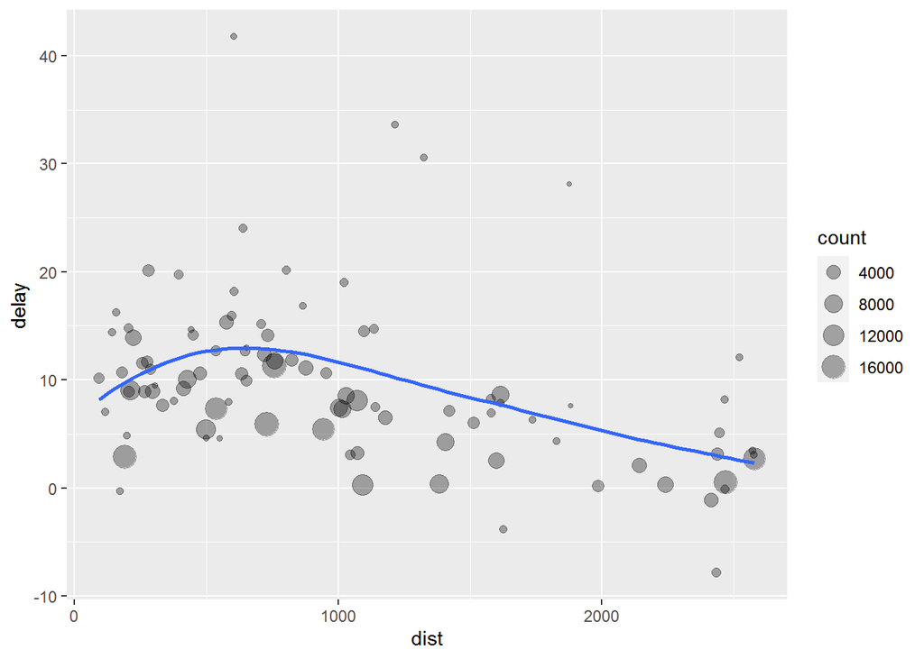

```r
# 3. 잡음이 많은 점과 호놀룰루 공항(다음으로 먼 공항보다 거의 두 배가 먼 공항)을 제거하는 필터링.
delay <- filter(delay, count > 20, dest != "HNL")

# 지연시간은 거리에 따라 750마일까지는 증가하다가 감소하는 것 같습니다.
# 항로가 길수록 비행 중에 지연시간을 만회할 여력이 더 있는 것인가?
ggplot(data = delay, mapping = aes(x = dist, y = delay)) +
  geom_point(aes(size = count), alpha = 1/3) +
  geom_smooth(se = FALSE)
```

위 코드는 크게 상관없는 중간 데이터프레임들에 이름을 모두 지어 주어야 하기 때문에, 이름 짓는 것이 쉽지 않아서 분석 속도가 늦어집니다. 이 문제를 파이프, %>%로 해결하는 방법이 있습니다. 이 방법은 변형 자체에 초점을 맞춰서, 코드를 더 읽기 쉽게 만듭니다. 여기에서 제안된 것처럼 코드를 읽을 때 %>%를 ’그다음’으로 읽는 것이 좋습니다.

```r
# 그룹화하고, 그다음 요약하고, 그다음 필터링하라.
delays <- flights %>%
  group_by(dest) %>%
  summarise(
    count = n(),
    dist = mean(distance, na.rm = TRUE),
    delay = mean(arr_delay, na.rm = TRUE)
  ) %>%
  filter(count > 20, dest != "HNL")
```

파이프를 사용하여 다중 작업을 왼쪽에서 오른쪽으로, 위에서 아래로 읽을 수 있게 다시 쓸 수 있습니다. 파이프를 사용하면 코드 가독성이 훨씬 좋아집니다. 파이프로 작업하는 것은 tidyverse에 속하기 위한 핵심 기준 중 하나입니다.

#### 3.6.2 결측값

```r
# na.rm 인수를 설정하지 않으면 결측값이 많이 생깁니다.
flights %>%
  group_by(year, month, day) %>%
  summarise(mean = mean(dep_delay))
```

```
## # A tibble: 365 x 4
## # Groups:   year, month [12]
##     year month   day  mean
##    <int> <int> <int> <dbl>
##  1  2013     1     1    NA
##  2  2013     1     2    NA
##  3  2013     1     3    NA
##  4  2013     1     4    NA
##  5  2013     1     5    NA
##  6  2013     1     6    NA
##  7  2013     1     7    NA
##  8  2013     1     8    NA
##  9  2013     1     9    NA
## 10  2013     1    10    NA
## # ... with 355 more rows
```

집계 함수는 결측값에 관한 일반적인 법칙(즉, 입력에 결측값이 있으면 출력도 결측값이 된다)을 따르기 때문입니다. 모든 집계 함수에는 na.rm 인수가 있어서 계산 전에 결측값들을 제거할 수 있습니다.

```r
flights %>%
  group_by(year, month, day) %>%
  summarise(mean = mean(dep_delay, na.rm = TRUE))
```

```
## # A tibble: 365 x 4
## # Groups:   year, month [12]
##     year month   day  mean
##    <int> <int> <int> <dbl>
##  1  2013     1     1 11.5
##  2  2013     1     2 13.9
##  3  2013     1     3 11.0
##  4  2013     1     4  8.95
##  5  2013     1     5  5.73
##  6  2013     1     6  7.15
##  7  2013     1     7  5.42
##  8  2013     1     8  2.55
##  9  2013     1     9  2.28
## 10  2013     1    10  2.84
## # ... with 355 more rows
```

이 경우에서 결측값은 취소된 항공편을 나타내므로, 취소된 항공편을 제거하여 문제를 해결할 수 있습니다.

```r
not_cancelled <- flights %>%
  filter(!is.na(dep_delay), !is.na(arr_delay))

not_cancelled %>%
  group_by(year, month, day) %>%
  summarise(mean = mean(dep_delay))
```

```
## # A tibble: 365 x 4
## # Groups:   year, month [12]
##     year month   day  mean
##    <int> <int> <int> <dbl>
##  1  2013     1     1 11.4
##  2  2013     1     2 13.7
##  3  2013     1     3 10.9
##  4  2013     1     4  8.97
##  5  2013     1     5  5.73
##  6  2013     1     6  7.15
##  7  2013     1     7  5.42
##  8  2013     1     8  2.56
##  9  2013     1     9  2.30
## 10  2013     1    10  2.84
## # ... with 355 more rows
```

#### 3.6.3 카운트

집계를 수행할 때마다 카운트 `n()` 혹은, 결측이 아닌 값의 카운트 `sum(!is.na(x))`를 포함하는 것이 좋습니다. 이렇게 하면 매우 적은 양의 데이터를 기반으로 결론을 도출하지 않는지 확인할 수 있습니다.

```r
# 예를 들어 평균 지연시간이 가장 긴 항공기(꼬리 번호(tail number)로 식별)로 봅시다. 어떤 항공기들은 평균 5시간(300분)이 지연된 걸 알 수 있습니다.
delays <- not_cancelled %>%
  group_by(tailnum) %>%
  summarise(
    delay = mean(arr_delay)
  )
```

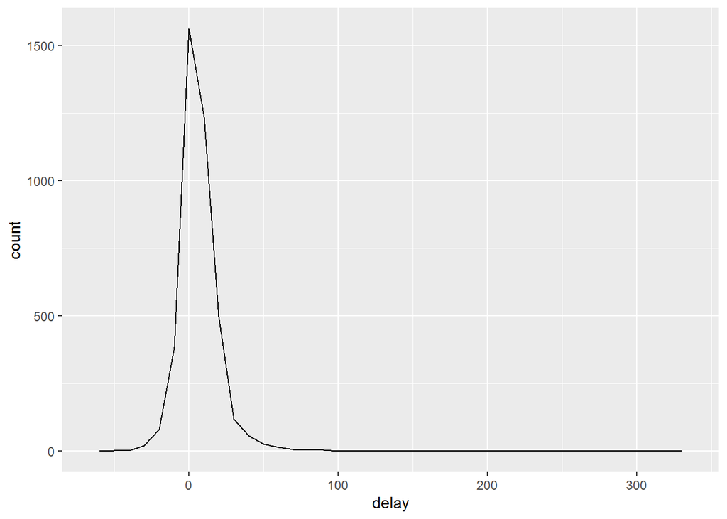

```r
ggplot(data = delays, mapping = aes(x = delay)) +
  geom_freqpoly(binwidth = 10)
```

```r
# 비행 횟수 대 평균 지연시간의 산점도를 그리면 더 많은 통찰력을 얻을 수 있습니다.
delays <- not_cancelled %>%
  group_by(tailnum) %>%
  summarise(
    delay = mean(arr_delay, na.rm = TRUE),
    n = n()
  )
```

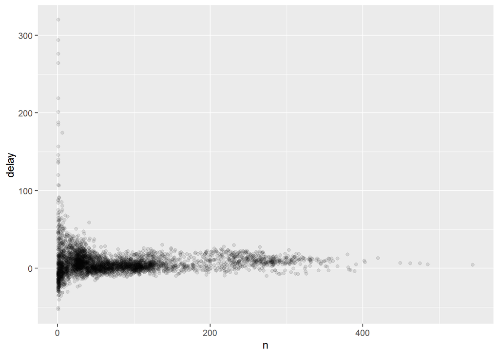

```r
ggplot(data = delays, mapping = aes(x = n, y = delay)) +
  geom_point(alpha = 1/10)
```

당연히 비행이 적을 때 평균지연시간에 변동이 훨씬 더 큽니다. 평균(혹은 다른 요약값) 대 그룹 크기의 플롯을 그리면 표본 크기가 커짐에 따라 변동이 줄어드는 것을 볼 수 있습니다. 이런 종류의 플롯을 살펴볼 때는, 관측값 개수가 가장 적은 그룹을 필터링하는 것이 좋은 경우가 많습니다. 심한 변동이 아닌 패턴이 더 잘 보이기 때문입니다.

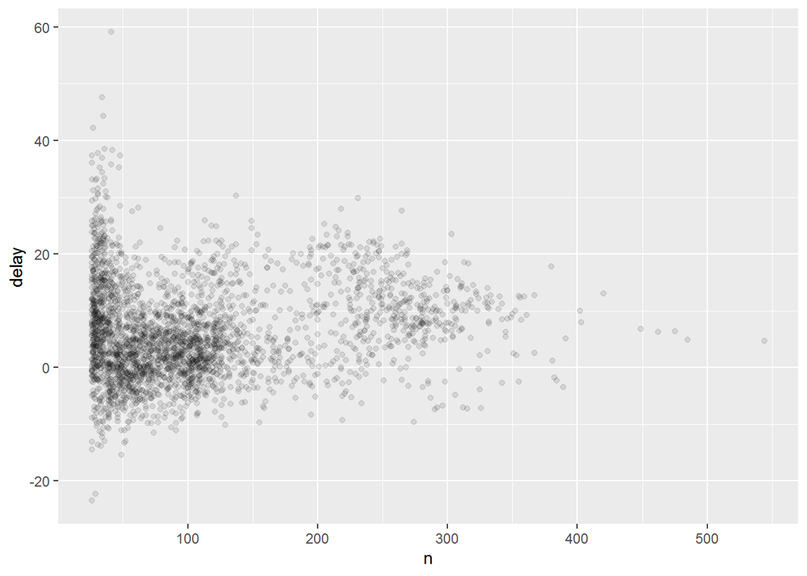

```r
# 이를 수행하는 다음 코드는 ggplot2를 dplyr 플로에 통합하는 편리한 패턴도 보여줍니다.
delays %>%
  filter(n > 25) %>%
  ggplot(mapping = aes(x = n, y = delay)) +
    geom_point(alpha = 1/10)
```

야구에서 타자의 평균 능력치가 타석 수와 어떻게 관련되었는지 살펴봅시다. 여기에서 Lahman 패키지 데이터를 사용하여 메이저리그의 모든 야구 선수의 타율(안타수/유호타석수)을 계산합니다. 타자의 기술(타율, ba로 측정)을 안타 기회 횟수에 대해 플롯을 그리면 두 가지 패턴이 보입니다. - 앞에서와 같이 집계값의 변동량을 데이터 포인트가 많아짐에 따라 감소합니다. - 기술 수준(ba)과 볼을 칠 기회(ab) 사이에 양의 상관관계가 있습니다. 팀이 누구를 타석에 내보낼지 선택할 때 당연히 최고의 선수를 선택할 것이기 때문입니다.

```r
# 보기 좋게 화면 출력되도록 티블로 변형
batting <- as_tibble(Lahman::Batting)

batters <- batting %>%
  group_by(playerID) %>%
  summarise(
    ba = sum(H, na.rm = TRUE) / sum(AB, na.rm = TRUE),
    ab = sum(AB, na.rm = TRUE)
  )
```

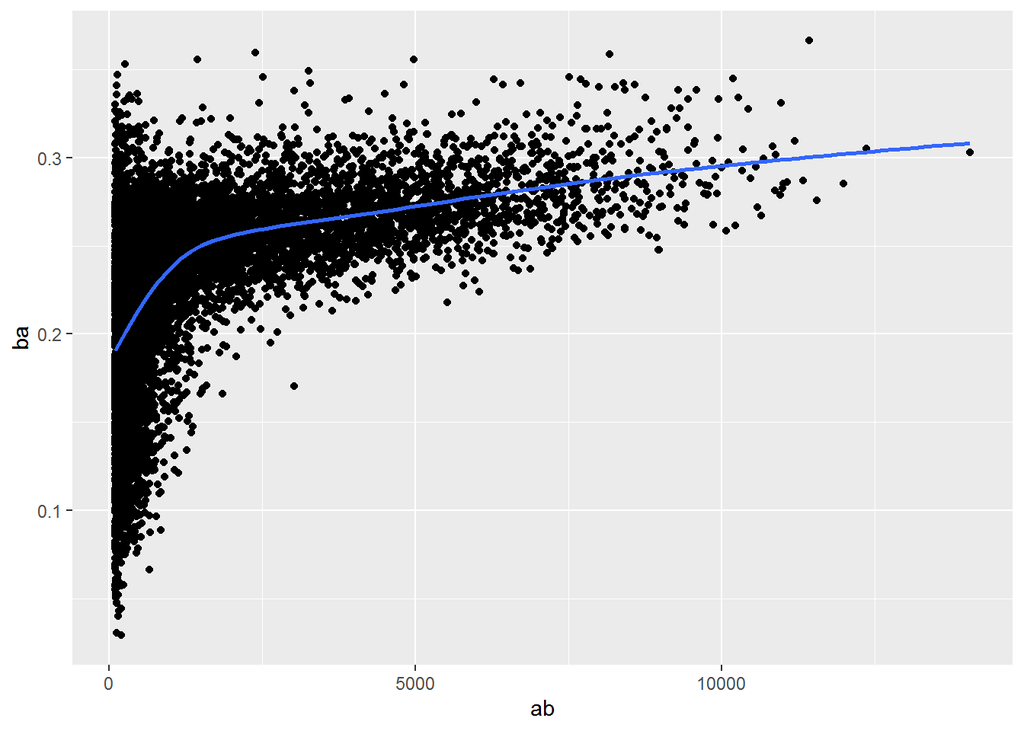

```r
batters %>%
  filter(ab > 100) %>%
  ggplot(mapping = aes(x = ab, y = ba)) +
    geom_point() +
    geom_smooth(se = FALSE)
```

이 사실은 순위에 중요한 영향을 줍니다. 단순히 desc(ba)로 정렬하면 평균 타율이 가장 높은 선수는 능력치가 좋은 것이 아니라 단순히 운이 좋은 선수들입니다.

```r
batters %>%
  arrange(desc(ba))
```

```
## # A tibble: 19,689 x 3
##    playerID     ba    ab
##    <chr>     <dbl> <int>
##  1 abramge01     1     1
##  2 alanirj01     1     1
##  3 alberan01     1     1
##  4 banisje01     1     1
##  5 bartocl01     1     1
##  6 bassdo01      1     1
##  7 birasst01     1     2
##  8 bruneju01     1     1
##  9 burnscb01     1     1
## 10 cammaer01     1     1
## # ... with 19,679 more rows
```

#### 3.6.4 유용한 요약 함수

##### 위치 측정값 median(x)

평균 mean(x)은 총합 나누기 길이이고, 중앙값 median(x)은 x의 50%가 위에 위치하고 50%는 아래에 위치하게 되는 값입니다.

```r
not_cancelled %>%
  group_by(year, month, day) %>%
  summarise(
    avg_delay1 = mean(arr_delay),
    # 지연시간의 평균:
    avg_delay2 = mean(arr_delay[arr_delay > 0])
  )
```

```
## # A tibble: 365 x 5
## # Groups:   year, month [12]
##     year month   day avg_delay1 avg_delay2
##    <int> <int> <int>      <dbl>      <dbl>
##  1  2013     1     1     12.7         32.5
##  2  2013     1     2     12.7         32.0
##  3  2013     1     3      5.73        27.7
##  4  2013     1     4     -1.93        28.3
##  5  2013     1     5     -1.53        22.6
##  6  2013     1     6      4.24        24.4
##  7  2013     1     7     -4.95        27.8
##  8  2013     1     8     -3.23        20.8
##  9  2013     1     9     -0.264       25.6
## 10  2013     1    10     -5.90        27.3
## # ... with 355 more rows
```

##### 산포 측정값 sd(x), IQR(x), mad(x)

- `sd(x)` 평균제곱편차, 혹은 표준편차, 산포의 표준 측정값
- `IQR()` 사분위범위
- `mad(x)` 중위절대편차, 이상값이 있을 때 더 유용할 수 있는 로버스트한 대체값

```r
# 왜 어떤 목적지는 그곳까지의 거리가 다른 곳보다 더 변동성이 있는가?
not_cancelled %>%
  group_by(dest) %>%
  summarise(distance_sd = sd(distance)) %>%
  arrange(desc(distance_sd))
```

```
## # A tibble: 104 x 2
##    dest  distance_sd
##    <chr>       <dbl>
##  1 EGE         10.5
##  2 SAN         10.4
##  3 SFO         10.2
##  4 HNL         10.0
##  5 SEA          9.98
##  6 LAS          9.91
##  7 PDX          9.87
##  8 PHX          9.86
##  9 LAX          9.66
## 10 IND          9.46
## # ... with 94 more rows
```

##### 순위 측정값 min(x), quntile(x, 0.25), max(x)

분위수는 중앙값의 일반화입니다. 예를 들어 quantile(x, 0.25)는 25%보다는 크고 나머지 75%보다는 작은 값을 찾습니다.

```r
# 각 날짜의 처음과 마지막 항공편은 언제 출발하는가?
not_cancelled %>%
  group_by(year, month, day) %>%
  summarise(
    first = min(dep_time),
    last = max(dep_time)
  )
```

```
## # A tibble: 365 x 5
## # Groups:   year, month [12]
##     year month   day first  last
##    <int> <int> <int> <int> <int>
##  1  2013     1     1   517  2356
##  2  2013     1     2    42  2354
##  3  2013     1     3    32  2349
##  4  2013     1     4    25  2358
##  5  2013     1     5    14  2357
##  6  2013     1     6    16  2355
##  7  2013     1     7    49  2359
##  8  2013     1     8   454  2351
##  9  2013     1     9     2  2252
## 10  2013     1    10     3  2320
## # ... with 355 more rows
```

##### 자리(position) 측정값 first(x), nth(x, 2), last(x)

x[1], x[2], x[leagth(x)]와 유사하게 동작하지만 자리가 존재하지 않을 때(예를 들어 두 개의 요소만 있는 그룹에서 세 번째 요소를 접근하려고 할 때) 기본값으로 설정할 수 있습니다. 예를 들어 각 날짜에 처음과 마지막 출발을 찾을 수 있습니다.

```r
not_cancelled %>%
  group_by(year, month, day) %>%
  summarise(
    first_dep = first(dep_time),
    last_dep = last(dep_time)
  )
```

```
## # A tibble: 365 x 5
## # Groups:   year, month [12]
##     year month   day first_dep last_dep
##    <int> <int> <int>     <int>    <int>
##  1  2013     1     1       517     2356
##  2  2013     1     2        42     2354
##  3  2013     1     3        32     2349
##  4  2013     1     4        25     2358
##  5  2013     1     5        14     2357
##  6  2013     1     6        16     2355
##  7  2013     1     7        49     2359
##  8  2013     1     8       454     2351
##  9  2013     1     9         2     2252
## 10  2013     1    10         3     2320
## # ... with 355 more rows
```

이 함수들은 순위로 필터링하는 데 사용할 수 있습니다. 필터링하면 모든 변수를 얻을 수 있는데, 각 관측값을 별도의 행으로 얻을 수 있습니다.

```r
not_cancelled %>%
  group_by(year, month, day) %>%
  mutate(r = min_rank(desc(dep_time))) %>%
  filter(r %in% range(r))
```

```
## # A tibble: 770 x 20
## # Groups:   year, month, day [365]
##     year month   day dep_time sched_dep_time dep_delay arr_time sched_arr_time
##    <int> <int> <int>    <int>          <int>     <dbl>    <int>          <int>
##  1  2013     1     1      517            515         2      830            819
##  2  2013     1     1     2356           2359        -3      425            437
##  3  2013     1     2       42           2359        43      518            442
##  4  2013     1     2     2354           2359        -5      413            437
##  5  2013     1     3       32           2359        33      504            442
##  6  2013     1     3     2349           2359       -10      434            445
##  7  2013     1     4       25           2359        26      505            442
##  8  2013     1     4     2358           2359        -1      429            437
##  9  2013     1     4     2358           2359        -1      436            445
## 10  2013     1     5       14           2359        15      503            445
## # ... with 760 more rows, and 12 more variables: arr_delay <dbl>,
## #   carrier <chr>, flight <int>, tailnum <chr>, origin <chr>, dest <chr>,
## #   air_time <dbl>, distance <dbl>, hour <dbl>, minute <dbl>, time_hour <dttm>,
## #   r <int>
```

##### 카운트

- `n()` 인수가 없고 현재 그룹의 크기를 반환
- `sum(!is.na(x))` 결측이 아닌 값의 수를 카운트
- `n_distinct(x)` 유일값 개수를 카운트

```r
# 어느 목적지에 항공사가 가장 많은가?
not_cancelled %>%
  group_by(dest) %>%
  summarise(carriers = n_distinct(carrier)) %>%
  arrange(desc(carriers))
```

```
## # A tibble: 104 x 2
##    dest  carriers
##    <chr>    <int>
##  1 ATL          7
##  2 BOS          7
##  3 CLT          7
##  4 ORD          7
##  5 TPA          7
##  6 AUS          6
##  7 DCA          6
##  8 DTW          6
##  9 IAD          6
## 10 MSP          6
## # ... with 94 more rows
```

카운트는 유용하기 때문에 dplyr에는 단순히 카운트만 원할 경우 사용할 수 있는 단순한 도우미 함수도 있습니다.

```r
not_cancelled %>%
  count(dest)
```

```
## # A tibble: 104 x 2
##    dest      n
##    <chr> <int>
##  1 ABQ     254
##  2 ACK     264
##  3 ALB     418
##  4 ANC       8
##  5 ATL   16837
##  6 AUS    2411
##  7 AVL     261
##  8 BDL     412
##  9 BGR     358
## 10 BHM     269
## # ... with 94 more rows
```

가중치 변수를 선택적으로 지정할 수도 있습니다. 예를 들어 이를 사용하여 항공기가 비행한 마일 수를 ’카운트(합)’할 수 있습니다.

```r
not_cancelled %>%
  count(tailnum, wt = distance)
```

```
## # A tibble: 4,037 x 2
##    tailnum      n
##    <chr>    <dbl>
##  1 D942DN    3418
##  2 N0EGMQ  239143
##  3 N10156  109664
##  4 N102UW   25722
##  5 N103US   24619
##  6 N104UW   24616
##  7 N10575  139903
##  8 N105UW   23618
##  9 N107US   21677
## 10 N108UW   32070
## # ... with 4,027 more rows
```

##### 논리형 값의 카운트와 비율 sum(x > 10), mean(y == 0)

수치형 함수를 사용할 경우 TRUE는 1로 FALSE는 0으로 바뀝니다. sum(x)는 TRUE의 개수를, mean(x)은 비율을 제공합니다.

```r
# 아침 5시 이전 항공편은 몇 편인가?
# (보통 전날 지연된 경우)
not_cancelled %>%
  group_by(year, month, day) %>%
  summarise(n_early = sum(dep_time < 500))
```

```
## # A tibble: 365 x 4
## # Groups:   year, month [12]
##     year month   day n_early
##    <int> <int> <int>   <int>
##  1  2013     1     1       0
##  2  2013     1     2       3
##  3  2013     1     3       4
##  4  2013     1     4       3
##  5  2013     1     5       3
##  6  2013     1     6       2
##  7  2013     1     7       2
##  8  2013     1     8       1
##  9  2013     1     9       3
## 10  2013     1    10       3
## # ... with 355 more rows
```

```r
# 한 시간 이상 지연된 항공편의 비율은?
not_cancelled %>%
  group_by(year, month, day) %>%
  summarise(hour_prop = mean(arr_delay > 60))
```

```
## # A tibble: 365 x 4
## # Groups:   year, month [12]
##     year month   day hour_prop
##    <int> <int> <int>     <dbl>
##  1  2013     1     1    0.0722
##  2  2013     1     2    0.0851
##  3  2013     1     3    0.0567
##  4  2013     1     4    0.0396
##  5  2013     1     5    0.0349
##  6  2013     1     6    0.0470
##  7  2013     1     7    0.0333
##  8  2013     1     8    0.0213
##  9  2013     1     9    0.0202
## 10  2013     1    10    0.0183
## # ... with 355 more rows
```

#### 3.6.5 여러 변수로 그룹화

여러 변수로 그룹화하면 각 요약값은 그룹화의 한 수준씩 벗겨냅니다. 이를 이용하면 데이터셋을 점진적으로 쉽게 요약할 수 있습니다.

```r
daily <- group_by(flights, year, month, day)
(per_day   <- summarise(daily, flights = n()))
```

```
## # A tibble: 365 x 4
## # Groups:   year, month [12]
##     year month   day flights
##    <int> <int> <int>   <int>
##  1  2013     1     1     842
##  2  2013     1     2     943
##  3  2013     1     3     914
##  4  2013     1     4     915
##  5  2013     1     5     720
##  6  2013     1     6     832
##  7  2013     1     7     933
##  8  2013     1     8     899
##  9  2013     1     9     902
## 10  2013     1    10     932
## # ... with 355 more rows
```

#### 3.6.6 그룹화 해제

그룹화를 제거하고 그룹화되지 않은 데이터 작업으로 돌아가려면 `ungroup()`을 사용합니다.

```r
daily %>%
  ungroup() %>%             # date 기반 그룹화 해제
  summarise(flights = n())  # 모든 항공편
```

```
## # A tibble: 1 x 1
##   flights
##     <int>
## 1  336776
```

### 3.7 그룹화 뮤테이트(와 필터링)

그룹화는 summarize()와 조합하여 사용하면 가장 유용하지만 mutate()와 filter()로 편리한 작업을 할 수도 있습니다.

```r
# 각 그룹에서 최악의 멤버들을 찾아봅시다.
flights_sml %>%
  group_by(year, month, day) %>%
  filter(rank(desc(arr_delay)) < 10)
```

```
## # A tibble: 3,306 x 7
## # Groups:   year, month, day [365]
##     year month   day dep_delay arr_delay distance air_time
##    <int> <int> <int>     <dbl>     <dbl>    <dbl>    <dbl>
##  1  2013     1     1       853       851      184       41
##  2  2013     1     1       290       338     1134      213
##  3  2013     1     1       260       263      266       46
##  4  2013     1     1       157       174      213       60
##  5  2013     1     1       216       222      708      121
##  6  2013     1     1       255       250      589      115
##  7  2013     1     1       285       246     1085      146
##  8  2013     1     1       192       191      199       44
##  9  2013     1     1       379       456     1092      222
## 10  2013     1     2       224       207      550       94
## # ... with 3,296 more rows
```

```r
# 기준값보다 큰 그룹을 모두 찾아봅시다.
popular_dests <- flights %>%
  group_by(dest) %>%
  filter(n() > 365)
popular_dests
```

```
## # A tibble: 332,577 x 19
## # Groups:   dest [77]
##     year month   day dep_time sched_dep_time dep_delay arr_time sched_arr_time
##    <int> <int> <int>    <int>          <int>     <dbl>    <int>          <int>
##  1  2013     1     1      517            515         2      830            819
##  2  2013     1     1      533            529         4      850            830
##  3  2013     1     1      542            540         2      923            850
##  4  2013     1     1      544            545        -1     1004           1022
##  5  2013     1     1      554            600        -6      812            837
##  6  2013     1     1      554            558        -4      740            728
##  7  2013     1     1      555            600        -5      913            854
##  8  2013     1     1      557            600        -3      709            723
##  9  2013     1     1      557            600        -3      838            846
## 10  2013     1     1      558            600        -2      753            745
## # ... with 332,567 more rows, and 11 more variables: arr_delay <dbl>,
## #   carrier <chr>, flight <int>, tailnum <chr>, origin <chr>, dest <chr>,
## #   air_time <dbl>, distance <dbl>, hour <dbl>, minute <dbl>, time_hour <dttm>
```

```r
# 그룹별 척도를 위해 표준화해봅시다.
popular_dests %>%
  filter(arr_delay > 0) %>%
  mutate(prop_delay = arr_delay / sum(arr_delay)) %>%
  select(year:day, dest, arr_delay, prop_delay)
```

```
## # A tibble: 131,106 x 6
## # Groups:   dest [77]
##     year month   day dest  arr_delay prop_delay
##    <int> <int> <int> <chr>     <dbl>      <dbl>
##  1  2013     1     1 IAH          11  0.000111
##  2  2013     1     1 IAH          20  0.000201
##  3  2013     1     1 MIA          33  0.000235
##  4  2013     1     1 ORD          12  0.0000424
##  5  2013     1     1 FLL          19  0.0000938
##  6  2013     1     1 ORD           8  0.0000283
##  7  2013     1     1 LAX           7  0.0000344
##  8  2013     1     1 DFW          31  0.000282
##  9  2013     1     1 ATL          12  0.0000400
## 10  2013     1     1 DTW          16  0.000116
## # ... with 131,096 more rows
```

그룹화 필터링은 그룹화 뮤테이트 이후 그룹화하지 않은 필터링이다. 저자는 데이터 응급 작업의 경우가 아니면 일반적으로 이를 사용하지 않는다고 합니다. 작업을 올바르게 했는지 확인하기 어렵기 때문입니다.